# DataB01A10

Daniel Paul

2022-11-29

**Load the necessary libraries**

```r
suppressMessages(
  if (!require('igraph')) {
    install.packages('igraph')
    library('igraph') })
suppressMessages(
  if (!require('maps')) {
    install.packages('maps')
    library('maps') })
suppressMessages(
  if (!require('DescTools')) {
    install.packages('DescTools')
    library('DescTools') })
suppressMessages(
  if (!require('viridis')) {
    install.packages('viridis')
    library('viridis') })
```

**Reading in the data** The data used for the assignment was NBA trade statistics from: https://www.reddit.com/r/nba/comments/ovis0z/2021_offseason_trade_tracker/ This contains season data about what players were traded to which teams during the 2021 Offseason. The data is read into a dataframe with the nodes being the teams of interest, and the arrows being from which team to which the players were traded.

This analysis is useful because offseason player movement frequently is a predictor of regular season success. The number of players moved may play a role in team success, or vice versa. The teams on the periphery who are not involved are shown without the edges.

The three letter abbreviations stand for the teams in the NBA.

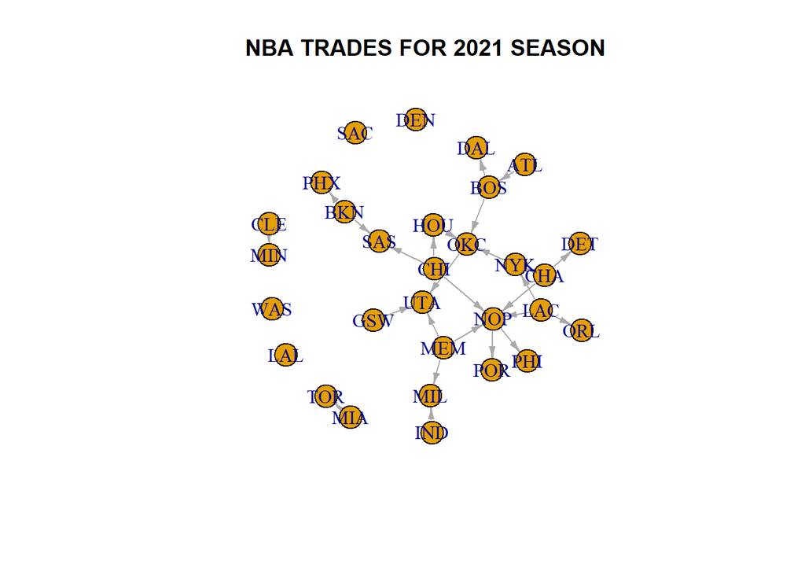

```r
library(igraph)

nodes_teams=read.csv(file='teams.csv', header=TRUE)
edges_trades = read.csv(file='trades.csv', header=TRUE)
players=strsplit(edges_trades$Team.1.Receives, ",")

origin=edges_trades$Team.1
dest=edges_trades$Team.2
vertices=nodes_teams$team


edges = data.frame("from" = origin, "to" = dest)
teams=data.frame(nodes_teams$team)
lay=data.frame(name=nodes_teams$team,latitude=nodes_teams$lat,longtitude=nodes_teams$lon)
g = graph.data.frame(edges, directed=T, vertices=lay)

g2= graph.data.frame(edges, directed=T, vertices=lay)#used later
g3= graph.data.frame(edges, directed=T, vertices=lay)#used later

location = layout.norm(as.matrix(lay[,2:3]))

plot(g,layout=layout.auto,main="NBA TRADES FOR 2021 SEASON", edge.arrow.size = 0.5, edge.arrow.width = 0.75,rescale=TRUE)
```

**Most Active Teams** The teams who traded away the most players are shown with the enlarged vertex, likewise the teams who did not trade as many player are show with the barely visible nodes. The degree is the measure used for the vertex size. Scaling respective to the outdegree.

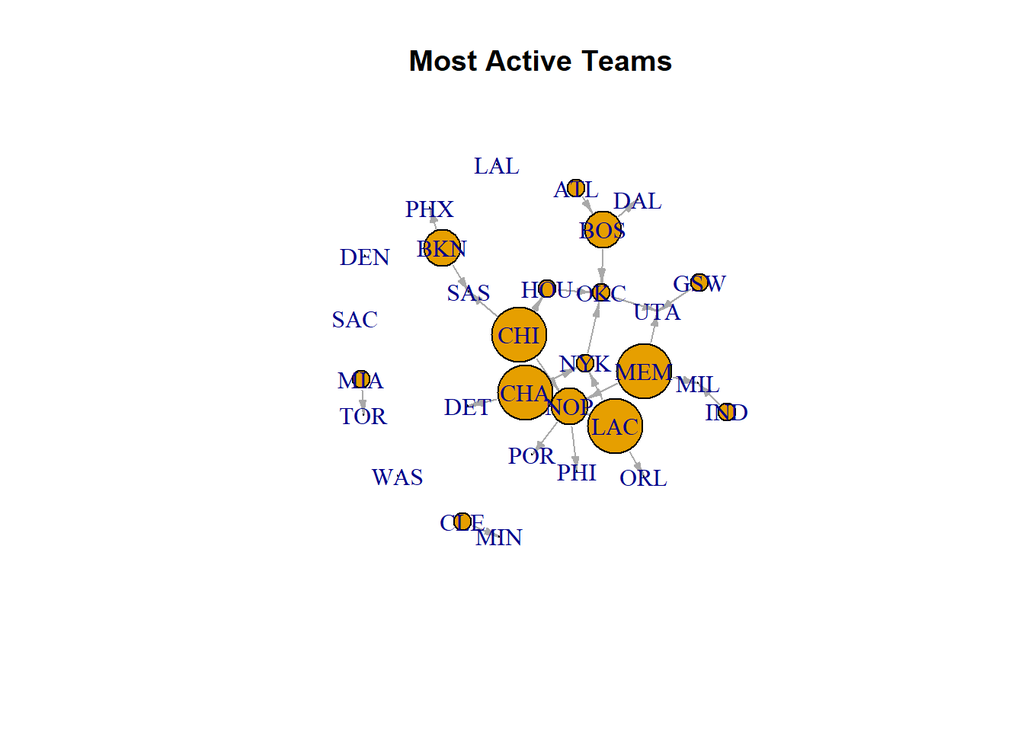

```r
V(g)$size = degree(g, mode = "out")*10
plot(g,layout=layout.auto,main="Most Active Teams", edge.arrow.size = 0.5, edge.arrow.width = 0.75,rescale=TRUE)
```

**NBA Teams mapped**

The locations of the teams in the cities of which are in the US (all but the Toronto Raptors) are mapped in red, the black lines between the red points show all teams that exchanged players. The distance players have to travel is readily visible from this map.

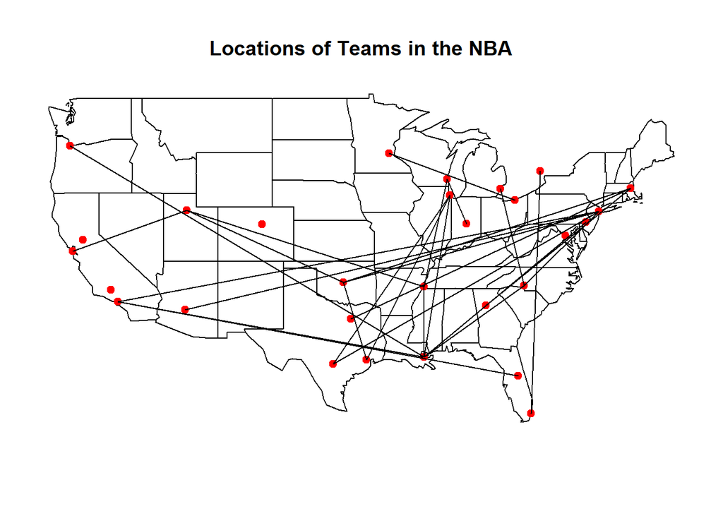

```r
library(maps)

map("state")
points(lay$longtitude,lay$latitude,col="red",pch = 19)
segments(x0=lay$longtitude[match(edges$from, lay$name)],y0=lay$latitude[match(edges$from, lay$name)],x1=lay$longtitude[match(edges$to, lay$name)],y1=lay$latitude[match(edges$to, lay$name)])
title("Locations of Teams in the NBA")
```

**Distances measure**

In the case of NBA teams trading players the distances measure can be interpreted as players moving from one team to another, with the number associated to each team being how many teams are in between the player traded from one team to another. With inf representing teams where if you look at trade connections it isn’t possible to get to said team.

```r
writeLines("Distances of the graph:")
```

```
## Distances of the graph:
```

```r
distances(g)
```

```
##     ATL BOS CHA CHI DAL CLE DEN DET GSW HOU IND LAC LAL MEM MIA MIL NOP NYK MIN
## ATL   0   1   4   4   2 Inf Inf   5   4   3   6   4 Inf   4 Inf   5   5   3 Inf
## BOS   1   0   3   3   1 Inf Inf   4   3   2   5   3 Inf   3 Inf   4   4   2 Inf
## CHA   4   3   0   2   4 Inf Inf   1   4   3   4   2 Inf   2 Inf   3   1   1 Inf
## CHI   4   3   2   0   4 Inf Inf   3   4   1   4   2 Inf   2 Inf   3   1   3 Inf
## DAL   2   1   4   4   0 Inf Inf   5   4   3   6   4 Inf   4 Inf   5   5   3 Inf
## CLE Inf Inf Inf Inf Inf   0 Inf Inf Inf Inf Inf Inf Inf Inf Inf Inf Inf Inf   1
## DEN Inf Inf Inf Inf Inf Inf   0 Inf Inf Inf Inf Inf Inf Inf Inf Inf Inf Inf Inf
## DET   5   4   1   3   5 Inf Inf   0   5   4   5   3 Inf   3 Inf   4   2   2 Inf
## GSW   4   3   4   4   4 Inf Inf   5   0   3   4   4 Inf   2 Inf   3   3   3 Inf
## HOU   3   2   3   1   3 Inf Inf   4   3   0   5   3 Inf   3 Inf   4   2   2 Inf
## IND   6   5   4   4   6 Inf Inf   5   4   5   0   4 Inf   2 Inf   1   3   5 Inf
## LAC   4   3   2   2   4 Inf Inf   3   4   3   4   0 Inf   2 Inf   3   1   1 Inf
## LAL Inf Inf Inf Inf Inf Inf Inf Inf Inf Inf Inf Inf   0 Inf Inf Inf Inf Inf Inf
## MEM   4   3   2   2   4 Inf Inf   3   2   3   2   2 Inf   0 Inf   1   1   3 Inf
## MIA Inf Inf Inf Inf Inf Inf Inf Inf Inf Inf Inf Inf Inf Inf   0 Inf Inf Inf Inf
## MIL   5   4   3   3   5 Inf Inf   4   3   4   1   3 Inf   1 Inf   0   2   4 Inf
## NOP   5   4   1   1   5 Inf Inf   2   3   2   3   1 Inf   1 Inf   2   0   2 Inf
## NYK   3   2   1   3   3 Inf Inf   2   3   2   5   1 Inf   3 Inf   4   2   0 Inf
## MIN Inf Inf Inf Inf Inf   1 Inf Inf Inf Inf Inf Inf Inf Inf Inf Inf Inf Inf   0
## OKC   2   1   2   2   2 Inf Inf   3   2   1   4   2 Inf   2 Inf   3   3   1 Inf
## ORL   5   4   3   3   5 Inf Inf   4   5   4   5   1 Inf   3 Inf   4   2   2 Inf
## PHI   6   5   2   2   6 Inf Inf   3   4   3   4   2 Inf   2 Inf   3   1   3 Inf
## PHX   7   6   5   3   7 Inf Inf   6   7   4   7   5 Inf   5 Inf   6   4   6 Inf
## POR   6   5   2   2   6 Inf Inf   3   4   3   4   2 Inf   2 Inf   3   1   3 Inf
## SAC Inf Inf Inf Inf Inf Inf Inf Inf Inf Inf Inf Inf Inf Inf Inf Inf Inf Inf Inf
## TOR Inf Inf Inf Inf Inf Inf Inf Inf Inf Inf Inf Inf Inf Inf   1 Inf Inf Inf Inf
## UTA   3   2   3   3   3 Inf Inf   4   1   2   3   3 Inf   1 Inf   2   2   2 Inf
## WAS Inf Inf Inf Inf Inf Inf Inf Inf Inf Inf Inf Inf Inf Inf Inf Inf Inf Inf Inf
## BKN   6   5   4   2   6 Inf Inf   5   6   3   6   4 Inf   4 Inf   5   3   5 Inf
## SAS   5   4   3   1   5 Inf Inf   4   5   2   5   3 Inf   3 Inf   4   2   4 Inf
##     OKC ORL PHI PHX POR SAC TOR UTA WAS BKN SAS
## ATL   2   5   6   7   6 Inf Inf   3 Inf   6   5
## BOS   1   4   5   6   5 Inf Inf   2 Inf   5   4
## CHA   2   3   2   5   2 Inf Inf   3 Inf   4   3
## CHI   2   3   2   3   2 Inf Inf   3 Inf   2   1
## DAL   2   5   6   7   6 Inf Inf   3 Inf   6   5
## CLE Inf Inf Inf Inf Inf Inf Inf Inf Inf Inf Inf
## DEN Inf Inf Inf Inf Inf Inf Inf Inf Inf Inf Inf
## DET   3   4   3   6   3 Inf Inf   4 Inf   5   4
## GSW   2   5   4   7   4 Inf Inf   1 Inf   6   5
## HOU   1   4   3   4   3 Inf Inf   2 Inf   3   2
## IND   4   5   4   7   4 Inf Inf   3 Inf   6   5
## LAC   2   1   2   5   2 Inf Inf   3 Inf   4   3
## LAL Inf Inf Inf Inf Inf Inf Inf Inf Inf Inf Inf
## MEM   2   3   2   5   2 Inf Inf   1 Inf   4   3
## MIA Inf Inf Inf Inf Inf Inf   1 Inf Inf Inf Inf
## MIL   3   4   3   6   3 Inf Inf   2 Inf   5   4
## NOP   3   2   1   4   1 Inf Inf   2 Inf   3   2
## NYK   1   2   3   6   3 Inf Inf   2 Inf   5   4
## MIN Inf Inf Inf Inf Inf Inf Inf Inf Inf Inf Inf
## OKC   0   3   4   5   4 Inf Inf   1 Inf   4   3
## ORL   3   0   3   6   3 Inf Inf   4 Inf   5   4
## PHI   4   3   0   5   2 Inf Inf   3 Inf   4   3
## PHX   5   6   5   0   5 Inf Inf   6 Inf   1   2
## POR   4   3   2   5   0 Inf Inf   3 Inf   4   3
## SAC Inf Inf Inf Inf Inf   0 Inf Inf Inf Inf Inf
## TOR Inf Inf Inf Inf Inf Inf   0 Inf Inf Inf Inf
## UTA   1   4   3   6   3 Inf Inf   0 Inf   5   4
## WAS Inf Inf Inf Inf Inf Inf Inf Inf   0 Inf Inf
## BKN   4   5   4   1   4 Inf Inf   5 Inf   0   1
## SAS   3   4   3   2   3 Inf Inf   4 Inf   1   0
```

**Dijkstra’s Algorithm**

Dijkstra’s algorithm for finding the shortest paths between nodes in the graph is applied. So again looking at the shortest number of teams are needed to see the consecutive trades from team to team. The dijkstra algorithm looks at both in and out mode of each team.

```r
writeLines("Distances (in) of the graph:")
```

```
## Distances (in) of the graph:
```

```r
distances(g, mode = "in",algorithm ="dijkstra")
```

```
##     ATL BOS CHA CHI DAL CLE DEN DET GSW HOU IND LAC LAL MEM MIA MIL NOP NYK MIN
## ATL   0 Inf Inf Inf Inf Inf Inf Inf Inf Inf Inf Inf Inf Inf Inf Inf Inf Inf Inf
## BOS   1   0 Inf Inf Inf Inf Inf Inf Inf Inf Inf Inf Inf Inf Inf Inf Inf Inf Inf
## CHA Inf Inf   0 Inf Inf Inf Inf Inf Inf Inf Inf Inf Inf Inf Inf Inf Inf Inf Inf
## CHI Inf Inf Inf   0 Inf Inf Inf Inf Inf Inf Inf Inf Inf Inf Inf Inf Inf Inf Inf
## DAL   2   1 Inf Inf   0 Inf Inf Inf Inf Inf Inf Inf Inf Inf Inf Inf Inf Inf Inf
## CLE Inf Inf Inf Inf Inf   0 Inf Inf Inf Inf Inf Inf Inf Inf Inf Inf Inf Inf Inf
## DEN Inf Inf Inf Inf Inf Inf   0 Inf Inf Inf Inf Inf Inf Inf Inf Inf Inf Inf Inf
## DET Inf Inf   1 Inf Inf Inf Inf   0 Inf Inf Inf Inf Inf Inf Inf Inf Inf Inf Inf
## GSW Inf Inf Inf Inf Inf Inf Inf Inf   0 Inf Inf Inf Inf Inf Inf Inf Inf Inf Inf
## HOU Inf Inf Inf   1 Inf Inf Inf Inf Inf   0 Inf Inf Inf Inf Inf Inf Inf Inf Inf
## IND Inf Inf Inf Inf Inf Inf Inf Inf Inf Inf   0 Inf Inf Inf Inf Inf Inf Inf Inf
## LAC Inf Inf Inf Inf Inf Inf Inf Inf Inf Inf Inf   0 Inf Inf Inf Inf Inf Inf Inf
## LAL Inf Inf Inf Inf Inf Inf Inf Inf Inf Inf Inf Inf   0 Inf Inf Inf Inf Inf Inf
## MEM Inf Inf Inf Inf Inf Inf Inf Inf Inf Inf Inf Inf Inf   0 Inf Inf Inf Inf Inf
## MIA Inf Inf Inf Inf Inf Inf Inf Inf Inf Inf Inf Inf Inf Inf   0 Inf Inf Inf Inf
## MIL Inf Inf Inf Inf Inf Inf Inf Inf Inf Inf   1 Inf Inf   1 Inf   0 Inf Inf Inf
## NOP Inf Inf   1   1 Inf Inf Inf Inf Inf Inf Inf   1 Inf   1 Inf Inf   0 Inf Inf
## NYK Inf Inf   1 Inf Inf Inf Inf Inf Inf Inf Inf   1 Inf Inf Inf Inf Inf   0 Inf
## MIN Inf Inf Inf Inf Inf   1 Inf Inf Inf Inf Inf Inf Inf Inf Inf Inf Inf Inf   0
## OKC   2   1   2   2 Inf Inf Inf Inf Inf   1 Inf   2 Inf Inf Inf Inf Inf   1 Inf
## ORL Inf Inf Inf Inf Inf Inf Inf Inf Inf Inf Inf   1 Inf Inf Inf Inf Inf Inf Inf
## PHI Inf Inf   2   2 Inf Inf Inf Inf Inf Inf Inf   2 Inf   2 Inf Inf   1 Inf Inf
## PHX Inf Inf Inf Inf Inf Inf Inf Inf Inf Inf Inf Inf Inf Inf Inf Inf Inf Inf Inf
## POR Inf Inf   2   2 Inf Inf Inf Inf Inf Inf Inf   2 Inf   2 Inf Inf   1 Inf Inf
## SAC Inf Inf Inf Inf Inf Inf Inf Inf Inf Inf Inf Inf Inf Inf Inf Inf Inf Inf Inf
## TOR Inf Inf Inf Inf Inf Inf Inf Inf Inf Inf Inf Inf Inf Inf   1 Inf Inf Inf Inf
## UTA   3   2   3   3 Inf Inf Inf Inf   1   2 Inf   3 Inf   1 Inf Inf Inf   2 Inf
## WAS Inf Inf Inf Inf Inf Inf Inf Inf Inf Inf Inf Inf Inf Inf Inf Inf Inf Inf Inf
## BKN Inf Inf Inf Inf Inf Inf Inf Inf Inf Inf Inf Inf Inf Inf Inf Inf Inf Inf Inf
## SAS Inf Inf Inf   1 Inf Inf Inf Inf Inf Inf Inf Inf Inf Inf Inf Inf Inf Inf Inf
##     OKC ORL PHI PHX POR SAC TOR UTA WAS BKN SAS
## ATL Inf Inf Inf Inf Inf Inf Inf Inf Inf Inf Inf
## BOS Inf Inf Inf Inf Inf Inf Inf Inf Inf Inf Inf
## CHA Inf Inf Inf Inf Inf Inf Inf Inf Inf Inf Inf
## CHI Inf Inf Inf Inf Inf Inf Inf Inf Inf Inf Inf
## DAL Inf Inf Inf Inf Inf Inf Inf Inf Inf Inf Inf
## CLE Inf Inf Inf Inf Inf Inf Inf Inf Inf Inf Inf
## DEN Inf Inf Inf Inf Inf Inf Inf Inf Inf Inf Inf
## DET Inf Inf Inf Inf Inf Inf Inf Inf Inf Inf Inf
## GSW Inf Inf Inf Inf Inf Inf Inf Inf Inf Inf Inf
## HOU Inf Inf Inf Inf Inf Inf Inf Inf Inf Inf Inf
## IND Inf Inf Inf Inf Inf Inf Inf Inf Inf Inf Inf
## LAC Inf Inf Inf Inf Inf Inf Inf Inf Inf Inf Inf
## LAL Inf Inf Inf Inf Inf Inf Inf Inf Inf Inf Inf
## MEM Inf Inf Inf Inf Inf Inf Inf Inf Inf Inf Inf
## MIA Inf Inf Inf Inf Inf Inf Inf Inf Inf Inf Inf
## MIL Inf Inf Inf Inf Inf Inf Inf Inf Inf Inf Inf
## NOP Inf Inf Inf Inf Inf Inf Inf Inf Inf Inf Inf
## NYK Inf Inf Inf Inf Inf Inf Inf Inf Inf Inf Inf
## MIN Inf Inf Inf Inf Inf Inf Inf Inf Inf Inf Inf
## OKC   0 Inf Inf Inf Inf Inf Inf Inf Inf Inf Inf
## ORL Inf   0 Inf Inf Inf Inf Inf Inf Inf Inf Inf
## PHI Inf Inf   0 Inf Inf Inf Inf Inf Inf Inf Inf
## PHX Inf Inf Inf   0 Inf Inf Inf Inf Inf   1 Inf
## POR Inf Inf Inf Inf   0 Inf Inf Inf Inf Inf Inf
## SAC Inf Inf Inf Inf Inf   0 Inf Inf Inf Inf Inf
## TOR Inf Inf Inf Inf Inf Inf   0 Inf Inf Inf Inf
## UTA   1 Inf Inf Inf Inf Inf Inf   0 Inf Inf Inf
## WAS Inf Inf Inf Inf Inf Inf Inf Inf   0 Inf Inf
## BKN Inf Inf Inf Inf Inf Inf Inf Inf Inf   0 Inf
## SAS Inf Inf Inf Inf Inf Inf Inf Inf Inf   1   0
```

```r
writeLines("\nDistances (out) of the graph:")
```

```
##
## Distances (out) of the graph:
```

```r
distances(g, mode = "out",algorithm ="dijkstra")
```

```
##     ATL BOS CHA CHI DAL CLE DEN DET GSW HOU IND LAC LAL MEM MIA MIL NOP NYK MIN
## ATL   0   1 Inf Inf   2 Inf Inf Inf Inf Inf Inf Inf Inf Inf Inf Inf Inf Inf Inf
## BOS Inf   0 Inf Inf   1 Inf Inf Inf Inf Inf Inf Inf Inf Inf Inf Inf Inf Inf Inf
## CHA Inf Inf   0 Inf Inf Inf Inf   1 Inf Inf Inf Inf Inf Inf Inf Inf   1   1 Inf
## CHI Inf Inf Inf   0 Inf Inf Inf Inf Inf   1 Inf Inf Inf Inf Inf Inf   1 Inf Inf
## DAL Inf Inf Inf Inf   0 Inf Inf Inf Inf Inf Inf Inf Inf Inf Inf Inf Inf Inf Inf
## CLE Inf Inf Inf Inf Inf   0 Inf Inf Inf Inf Inf Inf Inf Inf Inf Inf Inf Inf   1
## DEN Inf Inf Inf Inf Inf Inf   0 Inf Inf Inf Inf Inf Inf Inf Inf Inf Inf Inf Inf
## DET Inf Inf Inf Inf Inf Inf Inf   0 Inf Inf Inf Inf Inf Inf Inf Inf Inf Inf Inf
## GSW Inf Inf Inf Inf Inf Inf Inf Inf   0 Inf Inf Inf Inf Inf Inf Inf Inf Inf Inf
## HOU Inf Inf Inf Inf Inf Inf Inf Inf Inf   0 Inf Inf Inf Inf Inf Inf Inf Inf Inf
## IND Inf Inf Inf Inf Inf Inf Inf Inf Inf Inf   0 Inf Inf Inf Inf   1 Inf Inf Inf
## LAC Inf Inf Inf Inf Inf Inf Inf Inf Inf Inf Inf   0 Inf Inf Inf Inf   1   1 Inf
## LAL Inf Inf Inf Inf Inf Inf Inf Inf Inf Inf Inf Inf   0 Inf Inf Inf Inf Inf Inf
## MEM Inf Inf Inf Inf Inf Inf Inf Inf Inf Inf Inf Inf Inf   0 Inf   1   1 Inf Inf
## MIA Inf Inf Inf Inf Inf Inf Inf Inf Inf Inf Inf Inf Inf Inf   0 Inf Inf Inf Inf
## MIL Inf Inf Inf Inf Inf Inf Inf Inf Inf Inf Inf Inf Inf Inf Inf   0 Inf Inf Inf
## NOP Inf Inf Inf Inf Inf Inf Inf Inf Inf Inf Inf Inf Inf Inf Inf Inf   0 Inf Inf
## NYK Inf Inf Inf Inf Inf Inf Inf Inf Inf Inf Inf Inf Inf Inf Inf Inf Inf   0 Inf
## MIN Inf Inf Inf Inf Inf Inf Inf Inf Inf Inf Inf Inf Inf Inf Inf Inf Inf Inf   0
## OKC Inf Inf Inf Inf Inf Inf Inf Inf Inf Inf Inf Inf Inf Inf Inf Inf Inf Inf Inf
## ORL Inf Inf Inf Inf Inf Inf Inf Inf Inf Inf Inf Inf Inf Inf Inf Inf Inf Inf Inf
## PHI Inf Inf Inf Inf Inf Inf Inf Inf Inf Inf Inf Inf Inf Inf Inf Inf Inf Inf Inf
## PHX Inf Inf Inf Inf Inf Inf Inf Inf Inf Inf Inf Inf Inf Inf Inf Inf Inf Inf Inf
## POR Inf Inf Inf Inf Inf Inf Inf Inf Inf Inf Inf Inf Inf Inf Inf Inf Inf Inf Inf
## SAC Inf Inf Inf Inf Inf Inf Inf Inf Inf Inf Inf Inf Inf Inf Inf Inf Inf Inf Inf
## TOR Inf Inf Inf Inf Inf Inf Inf Inf Inf Inf Inf Inf Inf Inf Inf Inf Inf Inf Inf
## UTA Inf Inf Inf Inf Inf Inf Inf Inf Inf Inf Inf Inf Inf Inf Inf Inf Inf Inf Inf
## WAS Inf Inf Inf Inf Inf Inf Inf Inf Inf Inf Inf Inf Inf Inf Inf Inf Inf Inf Inf
## BKN Inf Inf Inf Inf Inf Inf Inf Inf Inf Inf Inf Inf Inf Inf Inf Inf Inf Inf Inf
## SAS Inf Inf Inf Inf Inf Inf Inf Inf Inf Inf Inf Inf Inf Inf Inf Inf Inf Inf Inf
##     OKC ORL PHI PHX POR SAC TOR UTA WAS BKN SAS
## ATL   2 Inf Inf Inf Inf Inf Inf   3 Inf Inf Inf
## BOS   1 Inf Inf Inf Inf Inf Inf   2 Inf Inf Inf
## CHA   2 Inf   2 Inf   2 Inf Inf   3 Inf Inf Inf
## CHI   2 Inf   2 Inf   2 Inf Inf   3 Inf Inf   1
## DAL Inf Inf Inf Inf Inf Inf Inf Inf Inf Inf Inf
## CLE Inf Inf Inf Inf Inf Inf Inf Inf Inf Inf Inf
## DEN Inf Inf Inf Inf Inf Inf Inf Inf Inf Inf Inf
## DET Inf Inf Inf Inf Inf Inf Inf Inf Inf Inf Inf
## GSW Inf Inf Inf Inf Inf Inf Inf   1 Inf Inf Inf
## HOU   1 Inf Inf Inf Inf Inf Inf   2 Inf Inf Inf
## IND Inf Inf Inf Inf Inf Inf Inf Inf Inf Inf Inf
## LAC   2   1   2 Inf   2 Inf Inf   3 Inf Inf Inf
## LAL Inf Inf Inf Inf Inf Inf Inf Inf Inf Inf Inf
## MEM Inf Inf   2 Inf   2 Inf Inf   1 Inf Inf Inf
## MIA Inf Inf Inf Inf Inf Inf   1 Inf Inf Inf Inf
## MIL Inf Inf Inf Inf Inf Inf Inf Inf Inf Inf Inf
## NOP Inf Inf   1 Inf   1 Inf Inf Inf Inf Inf Inf
## NYK   1 Inf Inf Inf Inf Inf Inf   2 Inf Inf Inf
## MIN Inf Inf Inf Inf Inf Inf Inf Inf Inf Inf Inf
## OKC   0 Inf Inf Inf Inf Inf Inf   1 Inf Inf Inf
## ORL Inf   0 Inf Inf Inf Inf Inf Inf Inf Inf Inf
## PHI Inf Inf   0 Inf Inf Inf Inf Inf Inf Inf Inf
## PHX Inf Inf Inf   0 Inf Inf Inf Inf Inf Inf Inf
## POR Inf Inf Inf Inf   0 Inf Inf Inf Inf Inf Inf
## SAC Inf Inf Inf Inf Inf   0 Inf Inf Inf Inf Inf
## TOR Inf Inf Inf Inf Inf Inf   0 Inf Inf Inf Inf
## UTA Inf Inf Inf Inf Inf Inf Inf   0 Inf Inf Inf
## WAS Inf Inf Inf Inf Inf Inf Inf Inf   0 Inf Inf
## BKN Inf Inf Inf   1 Inf Inf Inf Inf Inf   0   1
## SAS Inf Inf Inf Inf Inf Inf Inf Inf Inf Inf   0
```

**Eccentricity**

The eccentricity of a given team/vertex is its shortest path distance from the farthest other team/vertex in the graph. And of course farthest in this case is in reference to the teams and player being traded.

```r
writeLines("Eccentricity (all/in/out) of the graph:")
```

```
## Eccentricity (all/in/out) of the graph:
```

```r
eccentricity(g)
```

```
## ATL BOS CHA CHI DAL CLE DEN DET GSW HOU IND LAC LAL MEM MIA MIL NOP NYK MIN OKC
##   7   6   5   4   7   1   0   6   7   5   7   5   0   5   1   6   5   6   1   5
## ORL PHI PHX POR SAC TOR UTA WAS BKN SAS
##   6   6   7   6   0   1   6   0   6   5
```

```r
eccentricity(g, mode = "in")
```

```
## ATL BOS CHA CHI DAL CLE DEN DET GSW HOU IND LAC LAL MEM MIA MIL NOP NYK MIN OKC
##   0   1   0   0   2   0   0   1   0   1   0   0   0   0   0   1   1   1   1   2
## ORL PHI PHX POR SAC TOR UTA WAS BKN SAS
##   1   2   1   2   0   1   3   0   0   1
```

```r
eccentricity(g, mode = "out")
```

```
## ATL BOS CHA CHI DAL CLE DEN DET GSW HOU IND LAC LAL MEM MIA MIL NOP NYK MIN OKC
##   3   2   3   3   0   1   0   0   1   2   1   3   0   2   1   0   1   2   0   1
## ORL PHI PHX POR SAC TOR UTA WAS BKN SAS
##   0   0   0   0   0   0   0   0   1   0
```

```r
writeLines("Radius (all/in/out) of the graph:")
```

```
## Radius (all/in/out) of the graph:
```

```r
radius(g)
```

```
## [1] 0
```

```r
min(distances(g, mode = "in"))
```

```
## [1] 0
```

```r
min(distances(g, mode = "out"))
```

```
## [1] 0
```

```r
writeLines("Diameter (all/in/out) of the graph:")
```

```
## Diameter (all/in/out) of the graph:
```

```r
diameter(g)
```

```
## [1] 3
```

```r
diameter(g,unconnected=TRUE)
```

```
## [1] 3
```

```r
diameter(g,unconnected=TRUE)
```

```
## [1] 3
```

**Central Points, Periphery**

The peripheral vertices of a graph are the vertices with the maximum eccentricity. The central vertices of a graph are the vertices with the minimum eccentricity.

```r
e_out = eccentricity(g2, mode = "out")

writeLines("Central points:")
```

```
## Central points:
```

```r
V(g2)[which(e_out == min(e_out))]$name
```

```
##  [1] "DAL" "DEN" "DET" "LAL" "MIL" "MIN" "ORL" "PHI" "PHX" "POR" "SAC" "TOR"
## [13] "UTA" "WAS" "SAS"
```

```r
V(g2)[which(e_out == min(e_out))]$color = "violet"

writeLines("Periphery:")
```

```
## Periphery:
```

```r
V(g2)[which(e_out == max(e_out))]$name
```

```
## [1] "ATL" "CHA" "CHI" "LAC"
```

```r
V(g2)[which(e_out == max(e_out))]$color = "blue"
```

##The central points and periphery

Central points are violet, and the periphery is blue.

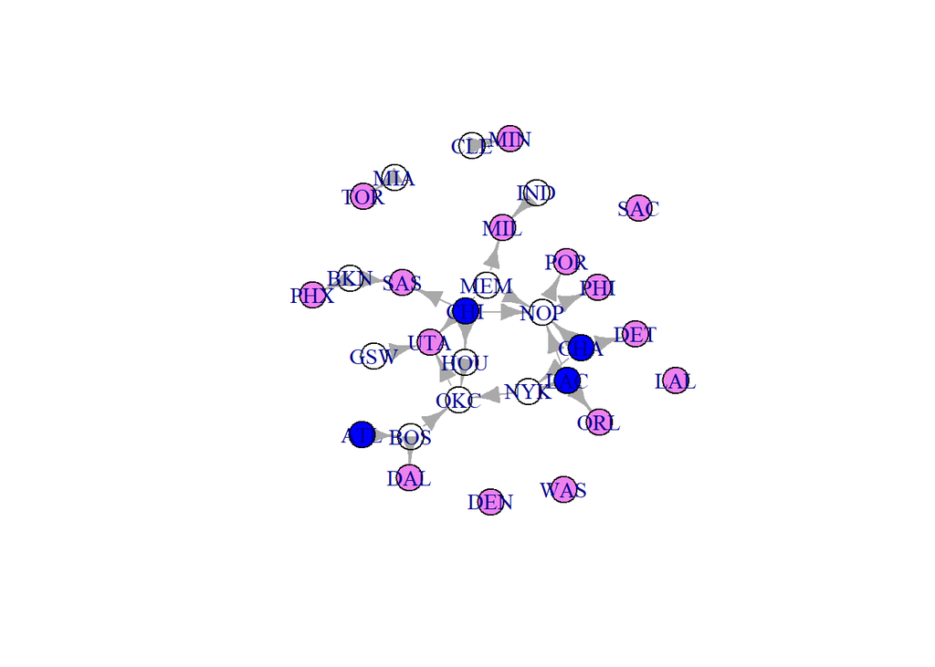

```r
plot(g2)
```

**Girth** This is the shortest cycle in the graph, again in this instance this is in reference to the number of consecutive teams that traded players.

```r
girth(g3)
```

```
## $girth
## [1] 4
##
## $circle
## + 4/30 vertices, named, from 2cd066e:
## [1] LAC NYK CHA NOP
```

**Edge Density** The ratio between the edges present in a graph and the maximum number of edges that the graph can contain. The number is low implying there were not many trades, however this is to be expected as the NBA season generally does not have many trades.

```r
edge_density(g3)
```

```
## [1] 0.02988506
```

The graph is not connected

```r
is.connected(g3, "weak")
```

```
## [1] FALSE
```

```r
is.connected(g3, "strong")
```

```
## [1] FALSE
```

The points which are once removed would disonnect the graph

```r
articulation_points(g3)
```

```
## + 11/30 vertices, named, from 2cd066e:
##  [1] BOS CHA LAC MIL MEM UTA NOP BKN SAS CHI OKC
```

```r
G_disconnected = induced_subgraph(g3, V(g3)$name[V(g3)$name != "NOP"])
is_connected(G_disconnected)
```

```
## [1] FALSE
```

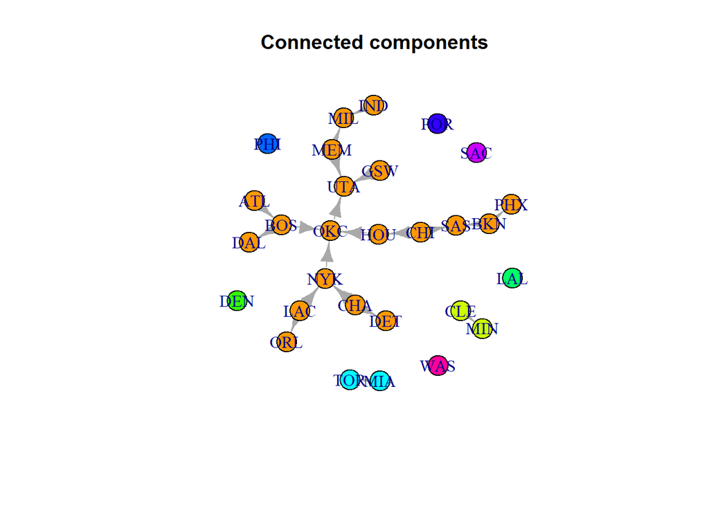

```r
comps = components(G_disconnected)$membership
colbar = rainbow(max(comps)+1) #colors of the rainbow
V(G_disconnected)$color = colbar[comps+1]

plot(G_disconnected)
title("Connected components")
```

```r
degree(g3, mode = "out")
```

```
## ATL BOS CHA CHI DAL CLE DEN DET GSW HOU IND LAC LAL MEM MIA MIL NOP NYK MIN OKC
##   1   2   3   3   0   1   0   0   1   1   1   3   0   3   1   0   2   1   0   1
## ORL PHI PHX POR SAC TOR UTA WAS BKN SAS
##   0   0   0   0   0   0   0   0   2   0
```

```r
degree(g3, mode = "in")
```

```
## ATL BOS CHA CHI DAL CLE DEN DET GSW HOU IND LAC LAL MEM MIA MIL NOP NYK MIN OKC
##   0   1   0   0   1   0   0   1   0   1   0   0   0   0   0   2   4   2   1   3
## ORL PHI PHX POR SAC TOR UTA WAS BKN SAS
##   1   1   1   1   0   1   3   0   0   2
```

```r
degree(g3)
```

```
## ATL BOS CHA CHI DAL CLE DEN DET GSW HOU IND LAC LAL MEM MIA MIL NOP NYK MIN OKC
##   1   3   3   3   1   1   0   1   1   2   1   3   0   3   1   2   6   3   1   4
## ORL PHI PHX POR SAC TOR UTA WAS BKN SAS
##   1   1   1   1   0   1   3   0   2   2
```

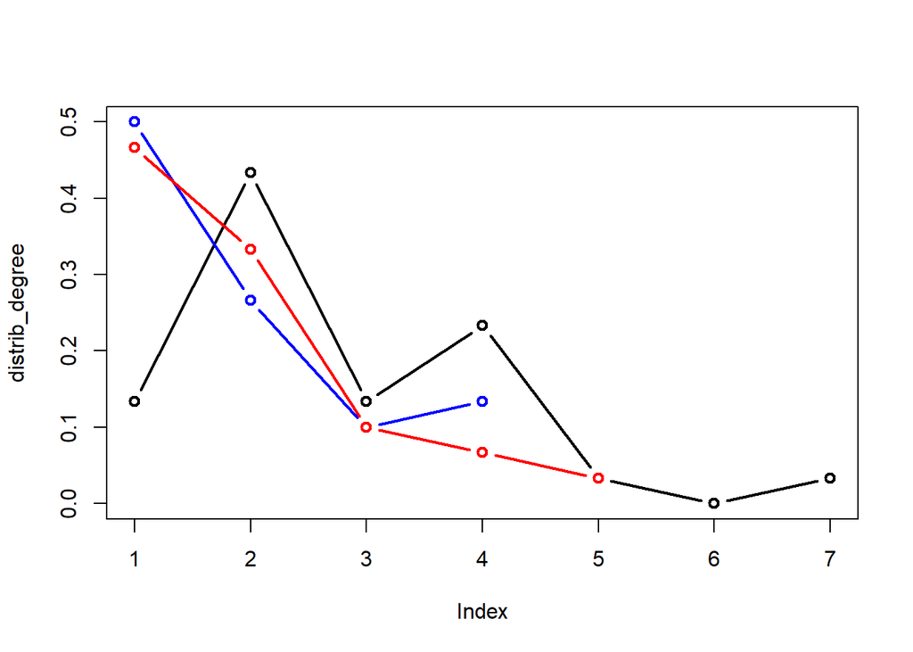

```r
distrib_outdegree = degree_distribution(g3, mode = "out")
distrib_indegree = degree_distribution(g3, mode = "in")
distrib_degree = degree_distribution(g3)

y_max = max(max(distrib_indegree, distrib_outdegree), distrib_degree)
plot(distrib_degree, type = "b", lwd = 2, col = "black", ylim = c(0, y_max))
points(distrib_outdegree, type = "b", lwd = 2, col = "blue")
points(distrib_indegree, type = "b", lwd = 2, col = "red")
```

```r
knn(g3, mode = "all")
```

```
## $knn
##      ATL      BOS      CHA      CHI      DAL      CLE      DEN      DET
## 3.000000 2.000000 3.333333 3.333333 3.000000 1.000000      NaN 3.000000
##      GSW      HOU      IND      LAC      LAL      MEM      MIA      MIL
## 3.000000 3.500000 2.000000 3.333333      NaN 3.666667 1.000000 2.000000
##      NOP      NYK      MIN      OKC      ORL      PHI      PHX      POR
## 2.333333 3.333333 1.000000 2.750000 3.000000 6.000000 2.000000 6.000000
##      SAC      TOR      UTA      WAS      BKN      SAS
##      NaN 1.000000 2.666667      NaN 1.500000 2.500000
##
## $knnk
## [1] 2.692308 2.375000 3.095238 2.750000      NaN 2.333333
```

```r
knn(g3, mode = "in")
```

```
## $knn
##      ATL      BOS      CHA      CHI      DAL      CLE      DEN      DET
##      NaN 1.000000      NaN      NaN 3.000000      NaN      NaN 3.000000
##      GSW      HOU      IND      LAC      LAL      MEM      MIA      MIL
##      NaN 3.000000      NaN      NaN      NaN      NaN      NaN 2.000000
##      NOP      NYK      MIN      OKC      ORL      PHI      PHX      POR
## 3.000000 3.000000 1.000000 2.666667 3.000000 6.000000 2.000000 6.000000
##      SAC      TOR      UTA      WAS      BKN      SAS
##      NaN 1.000000 2.666667      NaN      NaN 2.500000
##
## $knnk
## [1] 2.900000 2.500000 2.666667 3.000000
```

```r
knn(g3, mode = "out")
```

```
## $knn
##      ATL      BOS      CHA      CHI      DAL      CLE      DEN      DET
## 3.000000 2.500000 3.333333 3.333333      NaN 1.000000      NaN      NaN
##      GSW      HOU      IND      LAC      LAL      MEM      MIA      MIL
## 3.000000 4.000000 2.000000 3.333333      NaN 3.666667 1.000000      NaN
##      NOP      NYK      MIN      OKC      ORL      PHI      PHX      POR
## 1.000000 4.000000      NaN 3.000000      NaN      NaN      NaN      NaN
##      SAC      TOR      UTA      WAS      BKN      SAS
##      NaN      NaN      NaN      NaN 1.500000      NaN
##
## $knnk
## [1] 2.625000 1.666667 3.416667
```

**Knn plot**

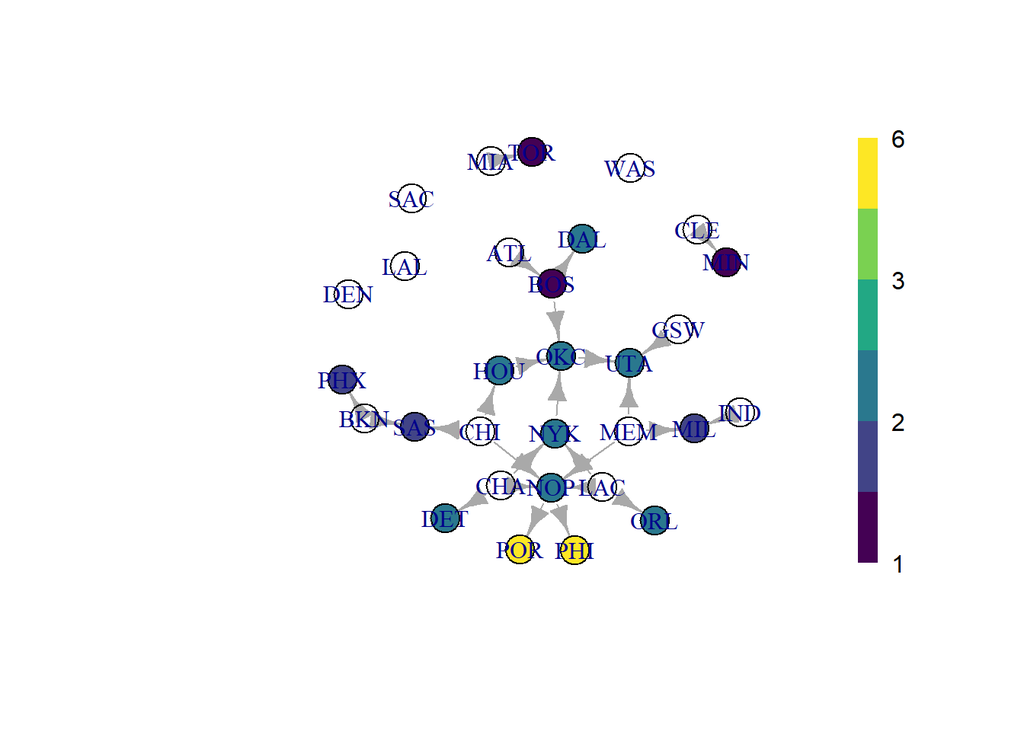

```r
library(DescTools)
library(viridis)

knn_in = knn(g3, mode = "in")$knn
knn_in_bar = sort(unique(round(knn_in)))
knn_vals = (ceiling(knn_in))

max=0
for(vals in knn_vals){
  if(!is.nan(vals)){
     if(vals>max){
       max=vals
    }
  }
}

colbar=viridis(max)
V(g3)$color = colbar[round(knn_in)]


plot(g3)
ColorLegend(x = "right", col = colbar, width = 0.1, inset = 0.1, labels = sprintf("%d", knn_in_bar))
```

**Coreness**

This measure looks at the subgroups of teams that are interlinked

```r
coreness(g3, "all")
```

```
## ATL BOS CHA CHI DAL CLE DEN DET GSW HOU IND LAC LAL MEM MIA MIL NOP NYK MIN OKC
##   1   1   2   2   1   1   0   1   1   2   1   2   0   2   1   1   2   2   1   2
## ORL PHI PHX POR SAC TOR UTA WAS BKN SAS
##   1   1   1   1   0   1   2   0   1   1
```

```r
coreness(g3, "in")
```

```
## ATL BOS CHA CHI DAL CLE DEN DET GSW HOU IND LAC LAL MEM MIA MIL NOP NYK MIN OKC
##   0   0   0   0   0   0   0   0   0   0   0   0   0   0   0   0   0   0   0   0
## ORL PHI PHX POR SAC TOR UTA WAS BKN SAS
##   0   0   0   0   0   0   0   0   0   0
```

```r
coreness(g3, "out")
```

```
## ATL BOS CHA CHI DAL CLE DEN DET GSW HOU IND LAC LAL MEM MIA MIL NOP NYK MIN OKC
##   0   0   0   0   0   0   0   0   0   0   0   0   0   0   0   0   0   0   0   0
## ORL PHI PHX POR SAC TOR UTA WAS BKN SAS
##   0   0   0   0   0   0   0   0   0   0
```

**Coreness Plot** These different groups are plotted with the colors.

This plots the different interlinked subgroups in the graph.

```r
cores = coreness(g3)
max=0
for(vals in cores){
  if(!is.nan(vals)){
     if(vals>max){
       max=vals
    }
  }
}

V(g3)$color = colbar[cores]
```

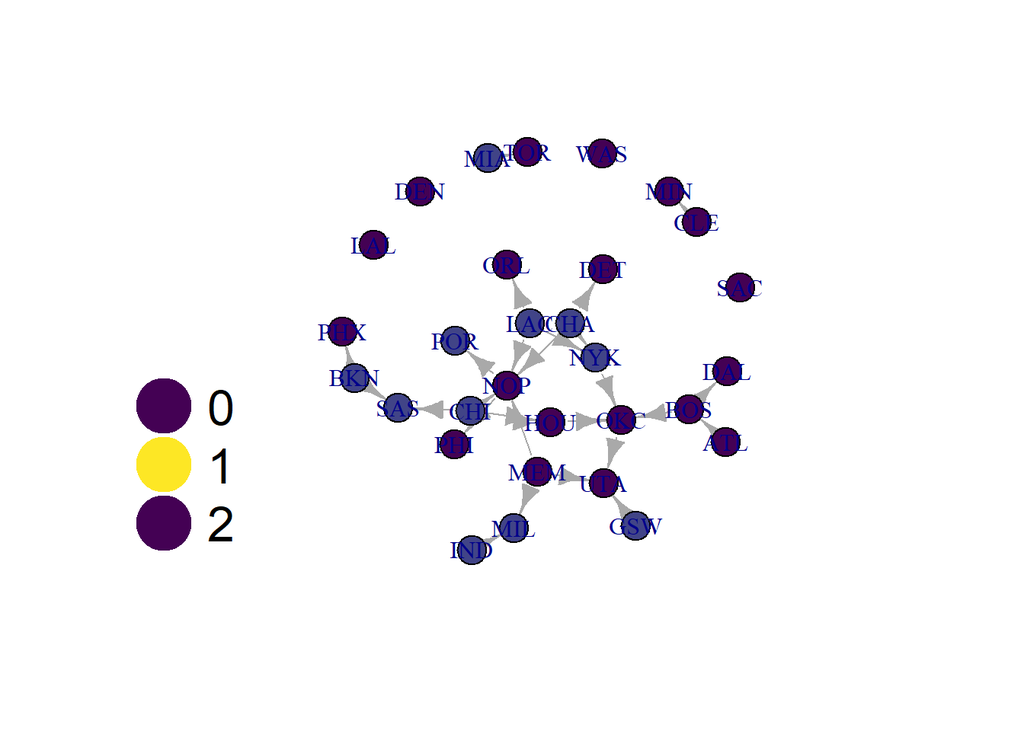

```r
colbar =viridis(max)

plot(g3)
legend("bottomleft", legend = sprintf("%d", sort(unique(cores))), pch = rep(19, length(unique(cores))), pt.cex = rep(5, length(unique(cores))), cex = 2, box.lty=0, col = colbar[sort(unique(cores))])
```

**Betweenness** The different components of a graph have a node that connects them, this looks at the team that serves as a bridge in player transfer.

```r
betweenness(g)
```

```
## ATL BOS CHA CHI DAL CLE DEN DET GSW HOU IND LAC LAL MEM MIA MIL NOP NYK MIN OKC
##   0   3   0   0   0   0   0   0   0   2   0   0   0   0   0   0   8   4   0   7
## ORL PHI PHX POR SAC TOR UTA WAS BKN SAS
##   0   0   0   0   0   0   0   0   0   0
```

**Betweenness plot** The players of relevance are plotted with the bridge serving as the teams that transferred a key player connecting a different parts of the graph

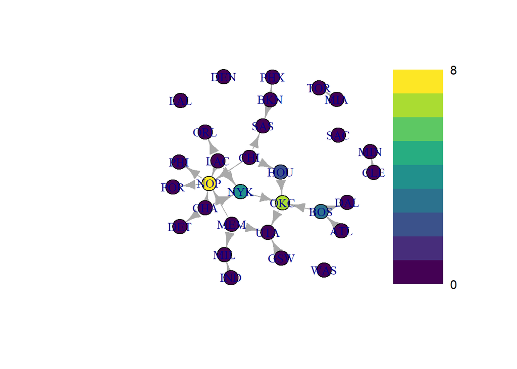

```r
betweenness_MB = betweenness(g3)
colbar = viridis(max(ceiling(betweenness_MB))+1)
V(g3)$color = colbar[round(betweenness_MB)+1]
colbar_str = sprintf("%d", range(unique(round(betweenness_MB))))

plot(g3)
ColorLegend(x = "right", col = colbar, width = 0.5, inset = 0.1,labels = colbar_str)
```

```r
closeness(g3, mode = "all")
```

```
##         ATL         BOS         CHA         CHI         DAL         CLE
## 0.011111111 0.014285714 0.017241379 0.018518519 0.011111111 1.000000000
##         DEN         DET         GSW         HOU         IND         LAC
##         NaN 0.012820513 0.012500000 0.016666667 0.010869565 0.017241379
##         LAL         MEM         MIA         MIL         NOP         NYK
##         NaN 0.018518519 1.000000000 0.013888889 0.020000000 0.016666667
##         MIN         OKC         ORL         PHI         PHX         POR
## 1.000000000 0.018518519 0.012820513 0.014285714 0.009259259 0.014285714
##         SAC         TOR         UTA         WAS         BKN         SAS
##         NaN 1.000000000 0.016666667         NaN 0.011363636 0.014285714
```

```r
closeness(g3, mode = "in")
```

```
##        ATL        BOS        CHA        CHI        DAL        CLE        DEN
##        NaN 1.00000000        NaN        NaN 0.33333333        NaN        NaN
##        DET        GSW        HOU        IND        LAC        LAL        MEM
## 1.00000000        NaN 1.00000000        NaN        NaN        NaN        NaN
##        MIA        MIL        NOP        NYK        MIN        OKC        ORL
##        NaN 0.50000000 0.25000000 0.50000000 1.00000000 0.09090909 1.00000000
##        PHI        PHX        POR        SAC        TOR        UTA        WAS
## 0.11111111 1.00000000 0.11111111        NaN 1.00000000 0.04761905        NaN
##        BKN        SAS
##        NaN 0.50000000
```

```r
closeness(g3, mode = "out")
```

```
##        ATL        BOS        CHA        CHI        DAL        CLE        DEN
## 0.12500000 0.25000000 0.08333333 0.08333333        NaN 1.00000000        NaN
##        DET        GSW        HOU        IND        LAC        LAL        MEM
##        NaN 1.00000000 0.33333333 1.00000000 0.08333333        NaN 0.14285714
##        MIA        MIL        NOP        NYK        MIN        OKC        ORL
## 1.00000000        NaN 0.50000000 0.33333333        NaN 1.00000000        NaN
##        PHI        PHX        POR        SAC        TOR        UTA        WAS
##        NaN        NaN        NaN        NaN        NaN        NaN        NaN
##        BKN        SAS
## 0.50000000        NaN
```

**Page Rank Algorithm**

```r
page_rankA = page.rank(g3)
max(page_rankA$vector)
```

```
## [1] 0.1192582
```

```r
colbar = viridis(max((page_rankA$vector)*100))
round((page_rankA$vector)*100)
```

```
## ATL BOS CHA CHI DAL CLE DEN DET GSW HOU IND LAC LAL MEM MIA MIL NOP NYK MIN OKC
##   2   4   2   2   4   2   2   3   2   3   2   2   2   2   2   4   4   3   4   9
## ORL PHI PHX POR SAC TOR UTA WAS BKN SAS
##   3   4   3   4   2   4  12   2   2   4
```

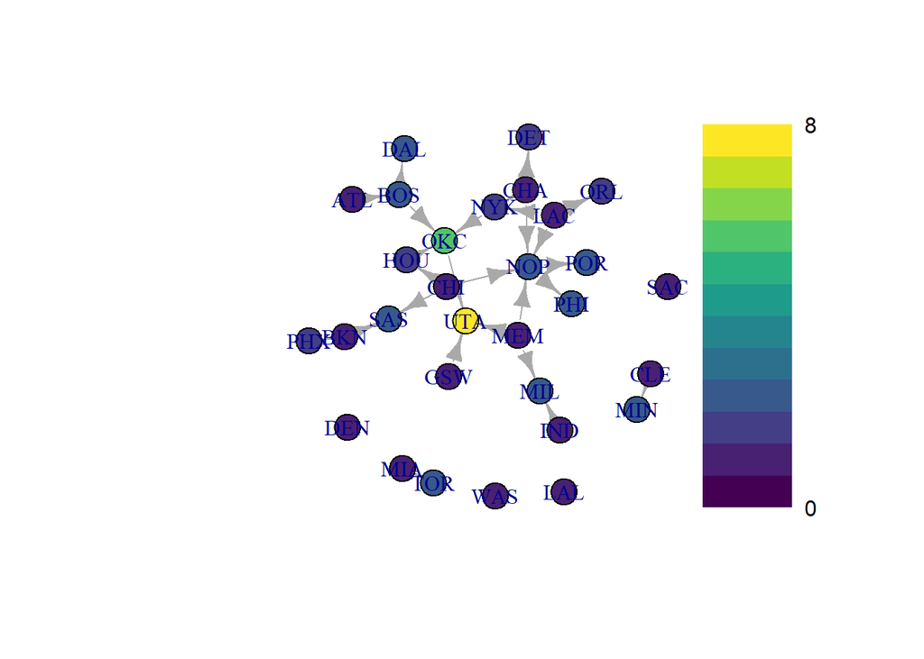

```r
V(g3)$color = colbar[round((page_rankA$vector)*100)]

plot(g3)
ColorLegend(x = "right", col = colbar, width = 0.5, inset = 0.1,labels = colbar_str)
```